# Project_3

Sahana Krishna Murthy

2024-11-20

Loading the data set into a dataframe:

```r
df <- read.csv("wineQuality.csv" , stringsAsFactors = TRUE)
summary(df)
```

```
##     fix.acid         vol.acid          citric           sugar
##  Min.   : 3.800   Min.   :0.0800   Min.   :0.0000   Min.   : 0.600
##  1st Qu.: 6.400   1st Qu.:0.2300   1st Qu.:0.2500   1st Qu.: 1.800
##  Median : 7.000   Median :0.2900   Median :0.3100   Median : 3.000
##  Mean   : 7.215   Mean   :0.3397   Mean   :0.3186   Mean   : 5.443
##  3rd Qu.: 7.700   3rd Qu.:0.4000   3rd Qu.:0.3900   3rd Qu.: 8.100
##  Max.   :15.900   Max.   :1.5800   Max.   :1.6600   Max.   :65.800
##    chlorides          free.sd          total.sd        density
##  Min.   :0.00900   Min.   :  1.00   Min.   :  6.0   Min.   :1.00
##  1st Qu.:0.03800   1st Qu.: 17.00   1st Qu.: 77.0   1st Qu.:2.00
##  Median :0.04700   Median : 29.00   Median :118.0   Median :2.00
##  Mean   :0.05603   Mean   : 30.53   Mean   :115.7   Mean   :1.97
##  3rd Qu.:0.06500   3rd Qu.: 41.00   3rd Qu.:156.0   3rd Qu.:2.00
##  Max.   :0.61100   Max.   :289.00   Max.   :440.0   Max.   :3.00
##        pH          sulphates         alcohol       label
##  Min.   :2.720   Min.   :0.2200   Min.   : 8.00   BAD :2384
##  1st Qu.:3.110   1st Qu.:0.4300   1st Qu.: 9.50   GOOD:4113
##  Median :3.210   Median :0.5100   Median :10.30
##  Mean   :3.219   Mean   :0.5313   Mean   :10.49
##  3rd Qu.:3.320   3rd Qu.:0.6000   3rd Qu.:11.30
##  Max.   :4.010   Max.   :2.0000   Max.   :14.90
```

```r
nrow(df)
```

```
## [1] 6497
```

The dataset shows a wide range of chemical properties, indicating diverse wine samples. Variables like volatile acidity, residual sugar, and alcohol levels may be key factors in distinguishing wine quality (“GOOD” vs. “BAD”).

Removing NA rows:

```r
suppressMessages(library(dplyr))
df_clean <- df %>% filter(complete.cases(.))
nrow(df)
```

```
## [1] 6497
```

No NA values found. Therefore, the total count of rows before and after running the above code block remains the same: 6497 rows.

Removing Outliers:

```r
suppressMessages(library(tidyverse))
# Function to calculate Z-scores
calculate_z_scores <- function(x) {
  (x - mean(x, na.rm = TRUE)) / sd(x, na.rm = TRUE)
}

# Add Z-scores for numeric predictors only in df_clean
z_scores <- df_clean %>%
  mutate(across(where(is.numeric), calculate_z_scores, .names = "z_{col}"))

summary(z_scores)
```

```
##     fix.acid         vol.acid          citric           sugar
##  Min.   : 3.800   Min.   :0.0800   Min.   :0.0000   Min.   : 0.600
##  1st Qu.: 6.400   1st Qu.:0.2300   1st Qu.:0.2500   1st Qu.: 1.800
##  Median : 7.000   Median :0.2900   Median :0.3100   Median : 3.000
##  Mean   : 7.215   Mean   :0.3397   Mean   :0.3186   Mean   : 5.443
##  3rd Qu.: 7.700   3rd Qu.:0.4000   3rd Qu.:0.3900   3rd Qu.: 8.100
##  Max.   :15.900   Max.   :1.5800   Max.   :1.6600   Max.   :65.800
##    chlorides          free.sd          total.sd        density
##  Min.   :0.00900   Min.   :  1.00   Min.   :  6.0   Min.   :1.00
##  1st Qu.:0.03800   1st Qu.: 17.00   1st Qu.: 77.0   1st Qu.:2.00
##  Median :0.04700   Median : 29.00   Median :118.0   Median :2.00
##  Mean   :0.05603   Mean   : 30.53   Mean   :115.7   Mean   :1.97
##  3rd Qu.:0.06500   3rd Qu.: 41.00   3rd Qu.:156.0   3rd Qu.:2.00
##  Max.   :0.61100   Max.   :289.00   Max.   :440.0   Max.   :3.00
##        pH          sulphates         alcohol       label        z_fix.acid
##  Min.   :2.720   Min.   :0.2200   Min.   : 8.00   BAD :2384   Min.   :-2.6344
##  1st Qu.:3.110   1st Qu.:0.4300   1st Qu.: 9.50   GOOD:4113   1st Qu.:-0.6289
##  Median :3.210   Median :0.5100   Median :10.30               Median :-0.1661
##  Mean   :3.219   Mean   :0.5313   Mean   :10.49               Mean   : 0.0000
##  3rd Qu.:3.320   3rd Qu.:0.6000   3rd Qu.:11.30               3rd Qu.: 0.3739
##  Max.   :4.010   Max.   :2.0000   Max.   :14.90               Max.   : 6.6989
##    z_vol.acid         z_citric           z_sugar         z_chlorides
##  Min.   :-1.5772   Min.   :-2.19266   Min.   :-1.0180   Min.   :-1.3425
##  1st Qu.:-0.6661   1st Qu.:-0.47230   1st Qu.:-0.7657   1st Qu.:-0.5148
##  Median :-0.3017   Median :-0.05941   Median :-0.5135   Median :-0.2579
##  Mean   : 0.0000   Mean   : 0.00000   Mean   : 0.0000   Mean   : 0.0000
##  3rd Qu.: 0.3665   3rd Qu.: 0.49111   3rd Qu.: 0.5584   3rd Qu.: 0.2559
##  Max.   : 7.5338   Max.   : 9.23057   Max.   :12.6858   Max.   :15.8410
##    z_free.sd          z_total.sd        z_density            z_pH
##  Min.   :-1.66345   Min.   :-1.9416   Min.   :-3.5447   Min.   :-3.10038
##  1st Qu.:-0.76202   1st Qu.:-0.6855   1st Qu.: 0.1114   1st Qu.:-0.67481
##  Median :-0.08594   Median : 0.0399   Median : 0.1114   Median :-0.05287
##  Mean   : 0.00000   Mean   : 0.0000   Mean   : 0.0000   Mean   : 0.00000
##  3rd Qu.: 0.59014   3rd Qu.: 0.7122   3rd Qu.: 0.1114   3rd Qu.: 0.63126
##  Max.   :14.56245   Max.   : 5.7368   Max.   : 3.7675   Max.   : 4.92265
##   z_sulphates        z_alcohol
##  Min.   :-2.0918   Min.   :-2.0892
##  1st Qu.:-0.6805   1st Qu.:-0.8316
##  Median :-0.1429   Median :-0.1608
##  Mean   : 0.0000   Mean   : 0.0000
##  3rd Qu.: 0.4619   3rd Qu.: 0.6776
##  Max.   : 9.8701   Max.   : 3.6959
```

```r
# Identify rows with outliers (|Z| > 3 in any column)
outliers <- z_scores %>%
  filter(if_any(starts_with("z_"), ~ abs(.) > 3))

cat("Outliers:", nrow(outliers), "rows\n")
```

```
## Outliers: 906 rows
```

```r
# Remove rows with outliers from df_clean
data_cleaned <- z_scores %>%
  filter(across(where(is.numeric), ~ !str_detect(cur_column(), "^z_") | abs(.) <= 3))
# Remove the 'z_*' columns before final output
data_cleaned <- data_cleaned %>%
  select(-starts_with("z_"))

nrow(data_cleaned)  # Check the number of rows after outlier removal
```

```
## [1] 5591
```

From the output of the above code, we can see that there are 906 outliers in this dataset. Which is why the total number of rows reduce to 5591 after running the above code block.

Splitting of data into training and test sets:

```r
set.seed(100)

s <- sample(length(data_cleaned$label) , round(0.7*length(data_cleaned$label)))
df.train <- data_cleaned[s,]
df.test <- data_cleaned[-s,]
```

The dataset is split into training and test sets by selecting 70 % of the rows for training and the rest 30% for testing the model performance.

Logistic Regression:

```r
log.out <- glm(label ~ . , data = df.train , family = binomial)

resp.prob = predict(log.out,newdata=df.test,type="response")
```

The above code block trains the df.train dataset using the logistic regression model. Where the target variable “label” is regressed upon the rest of the response variables.

ROC curve for Logistic Regression:

```r
suppressMessages(library(pROC))

(roc.log <- roc(df.test$label,resp.prob))
```

```
##
## Call:
## roc.default(response = df.test$label, predictor = resp.prob)
##
## Data: resp.prob in 623 controls (df.test$label BAD) < 1054 cases (df.test$label GOOD).
## Area under the curve: 0.7899
```

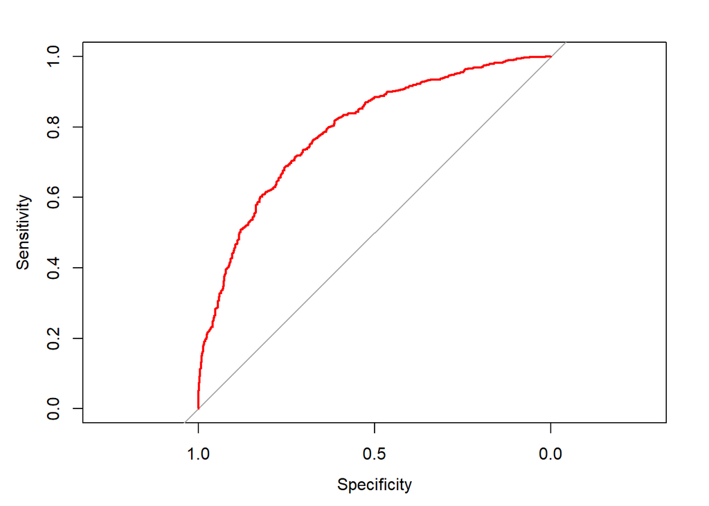

```r
plot(roc.log,col="red",xlim=c(1,0),ylim=c(0,1))
```

```r
roc.log
```

```
##
## Call:
## roc.default(response = df.test$label, predictor = resp.prob)
##
## Data: resp.prob in 623 controls (df.test$label BAD) < 1054 cases (df.test$label GOOD).
## Area under the curve: 0.7899
```

The above code block is used to plot the ROC curve for the logistic regression model.

AUC:

```r
log.auc <- round(roc.log$auc,3)
cat("AUC for logistic regression: ",log.auc,"\n")
```

```
## AUC for logistic regression:  0.79
```

The above code provides the area under the curve for logistic regression model. An AUC of 0.79 suggests that the logistic regression model has a fairly strong ability to separate the two classes. While it’s not perfect, the model performs better than random guessing and demonstrates reasonable discriminatory power.

Youden’s J statistic:

```r
log.J <- roc.log$sensitivities + roc.log$specificities - 1
w <- which.max(log.J)
cat("Optimum threshold for logistic regression: ",round(roc.log$thresholds[w],3),"\n")
```

```
## Optimum threshold for logistic regression:  0.654
```

```r
optimal_threshold <- roc.log$thresholds[w]
resp.pred = ifelse(resp.prob>optimal_threshold,"GOOD","BAD")
log.mcr <- round(mean(resp.pred!= df.test$label),3) # compressed MCR calculator
tab <- table(Predicted = resp.pred, Actual = df.test$label)
cat("Misclassification rate for logistic regression: " ,log.mcr)
```

```
## Misclassification rate for logistic regression:  0.288
```

```r
print(tab)
```

```
##          Actual
## Predicted BAD GOOD
##      BAD  471  331
##      GOOD 152  723
```

Random forest:

```r
suppressMessages(library(tidyverse))
suppressMessages(library(randomForest))
rf.out = randomForest(label~.,data=df.train,
importance=TRUE)
```

A Random Forest classifier is trained using the training dataset df.train, with the target variable label and all other variables as predictors.

ROC, AUC, J statistic for Random Forest:

```r
# Get predicted probabilities for the "GOOD" class
 resp.prob <- predict(rf.out, newdata = df.test, type = "prob")[, "GOOD"]

(roc.rf <- roc(df.test$label,resp.prob))
```

```
##
## Call:
## roc.default(response = df.test$label, predictor = resp.prob)
##
## Data: resp.prob in 623 controls (df.test$label BAD) < 1054 cases (df.test$label GOOD).
## Area under the curve: 0.8947
```

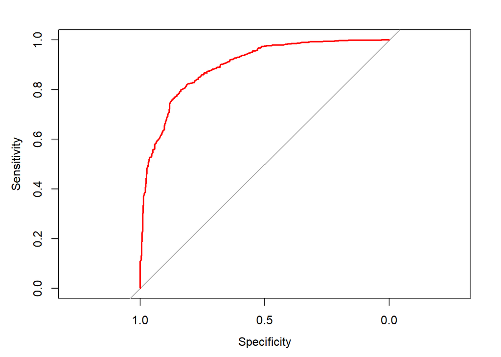

```r
plot(roc.rf,col="red",xlim=c(1,0),ylim=c(0,1))
```

```r
roc.rf
```

```
##
## Call:
## roc.default(response = df.test$label, predictor = resp.prob)
##
## Data: resp.prob in 623 controls (df.test$label BAD) < 1054 cases (df.test$label GOOD).
## Area under the curve: 0.8947
```

```r
rf.auc <- round(roc.rf$auc,3)
cat("AUC for Random Forest: ",round(roc.rf$auc,3),"\n")
```

```
## AUC for Random Forest:  0.895
```

```r
rf.J <- roc.rf$sensitivities + roc.rf$specificities - 1
w <- which.max(rf.J)
rf.J.tab <- rf.J[w]
print(rf.J.tab)
```

```
## [1] 0.6351376
```

```r
optimal_threshold <- roc.rf$thresholds[w]
cat("Optimum threshold for Random Forest: ",optimal_threshold,"\n")
```

```
## Optimum threshold for Random Forest:  0.645
```

```r
# Use the optimal threshold to classify the test data
resp.pred <- ifelse(resp.prob > optimal_threshold, "GOOD", "BAD")

# Calculate MCR
rf.mcr <- round(mean(resp.pred != df.test$label), 3)

# Print MCR
print(paste("Random Forest MCR:", rf.mcr))
```

```
## [1] "Random Forest MCR: 0.187"
```

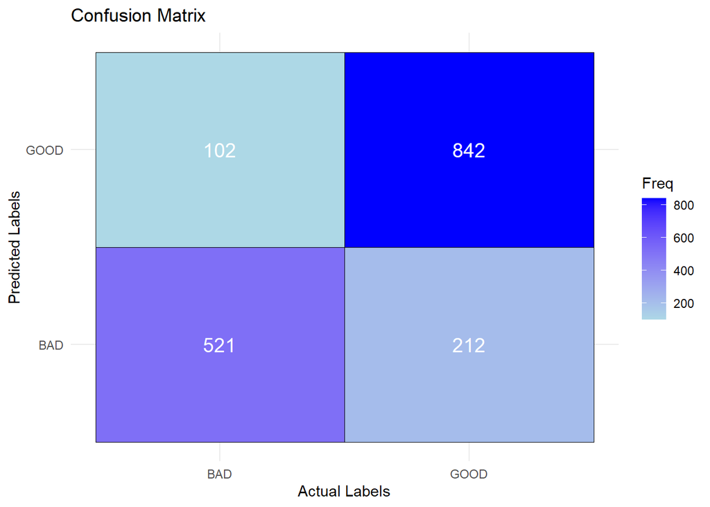

```r
confusion_matrix <- table(Predicted = resp.pred, Actual = df.test$label)
confusion_df <- as.data.frame(confusion_matrix)

ggplot(confusion_df, aes(x = Actual, y = Predicted, fill = Freq)) +
  geom_tile(color = "black") +
  geom_text(aes(label = Freq), color = "white", size = 5) +
  scale_fill_gradient(low = "lightblue", high = "blue") +
  labs(title = "Confusion Matrix", x = "Actual Labels", y = "Predicted Labels") +
  theme_minimal()
```

Gradient Boosting:

```r
set.seed(101)
suppressMessages(library(xgboost))

# Convert "GOOD" and "BAD" to numeric labels (1 for "GOOD", 0 for "BAD")
df.train$label <- as.numeric(df.train$label == "GOOD")
df.test$label <- as.numeric(df.test$label == "GOOD")

train <- xgb.DMatrix(data=as.matrix(df.train[,1:10]),label=df.train$label)
test <- xgb.DMatrix(data=as.matrix(df.test[,1:10]),label=df.test$label)

# Hyperparameters
params <- list(
  objective = "binary:logistic", # For binary classification
  eta = 0.1,                     # Learning rate
  max_depth = 6,                 # Maximum tree depth
  min_child_weight = 1,          # Minimum sum of instance weight in a child
  subsample = 0.8,               # Row sampling ratio
  colsample_bytree = 0.8         # Feature sampling ratio
)

# Cross-validation
xgb.cv.out <- xgb.cv(
  params = params,
  data = train,
  nrounds = 30,
  nfold = 5,
  verbose = 0,
  metrics = "auc" # Evaluate using AUC
)

# Identify the optimal number of trees
optimal_trees <- which.max(xgb.cv.out$evaluation_log$test_auc_mean)
auc.max <- max(xgb.cv.out$evaluation_log$test_auc_mean)
cat("The optimal number of trees is ", which.max(xgb.cv.out$evaluation_log$test_auc_mean), "\n")
```

```
## The optimal number of trees is  30
```

```r
cat("Best AUC: ", round(auc.max, 3), "\n")
```

```
## Best AUC:  0.809
```

The optimal number of trees identified through cross-validation is 30, suggesting that this is the most effective iteration for balancing model complexity and performance. The best AUC achieved during cross-validation is 0.809, indicating good performance in distinguishing between the “GOOD” and “BAD” classes.

```r
# Train final model
xgb.out <- xgboost(
  data = train,
  nrounds = optimal_trees,
  params = params,
  verbose = 0
)

# Predict probabilities
resp.prob <- predict(xgb.out, newdata = test)
```

The Gradient Boosting model was trained using the optimal number of trees (30) and specified hyperparameters. Probabilities for the test dataset were successfully predicted, ready for further evaluation such as thresholding, ROC analysis, or classification performance assessment.

ROC, AUC, J statistic for gradient boosting:

```r
# Get predicted probabilities for the "GOOD" class
(roc.gbm <- roc(df.test$label,resp.prob))
```

```
##
## Call:
## roc.default(response = df.test$label, predictor = resp.prob)
##
## Data: resp.prob in 623 controls (df.test$label 0) < 1054 cases (df.test$label 1).
## Area under the curve: 0.8207
```

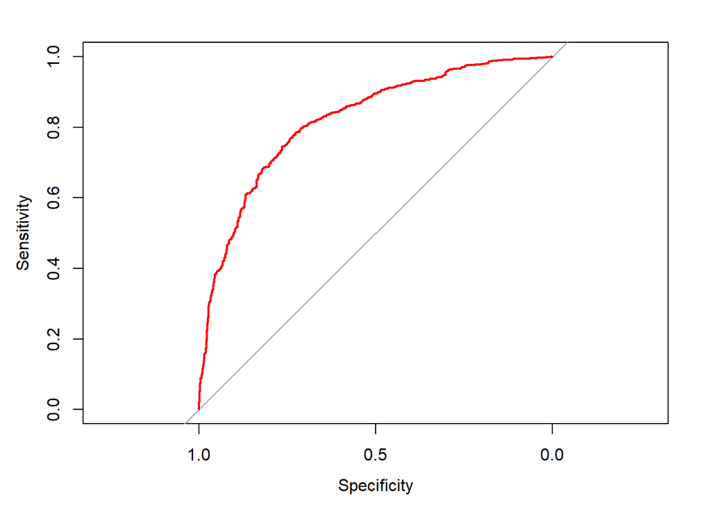

```r
plot(roc.gbm,col="red",xlim=c(1,0),ylim=c(0,1))
```

```r
roc.gbm
```

```
##
## Call:
## roc.default(response = df.test$label, predictor = resp.prob)
##
## Data: resp.prob in 623 controls (df.test$label 0) < 1054 cases (df.test$label 1).
## Area under the curve: 0.8207
```

```r
xgb.auc <- round(roc.gbm$auc,3)
cat("AUC for gradient boosting: ",xgb.auc,"\n")
```

```
## AUC for gradient boosting:  0.821
```

```r
xgb.J <- roc.gbm$sensitivities + roc.gbm$specificities - 1
w <- which.max(xgb.J)
cat("Optimum threshold for Gradient Boosting: ",round(roc.log$thresholds[w],3),"\n")
```

```
## Optimum threshold for Gradient Boosting:  0.606
```

```r
# Convert probabilities to predictions using the optimal threshold
resp.pred <- ifelse(resp.prob > optimal_threshold, 1, 0)

# Calculate Misclassification Rate (MCR)
xgb.mcr <- mean(resp.pred != df.test$label) # Now both are numeric
cat("Misclassification Rate (MCR): ", round(xgb.mcr, 3), "\n")
```

```
## Misclassification Rate (MCR):  0.252
```

```r
# Evaluate performance
confusion.mat <- table(Predicted = resp.pred, Actual = ifelse(df.test$label == 1, "GOOD", "BAD"))
accuracy <- sum(diag(confusion.mat)) / sum(confusion.mat)
cat("Confusion Matrix:\n")
```

```
## Confusion Matrix:
```

```r
print(confusion.mat)
```

```
##          Actual
## Predicted BAD GOOD
##         0 476  275
##         1 147  779
```

```r
cat("Accuracy: ", round(accuracy, 3), "\n")
```

```
## Accuracy:  0.748
```

AUC (Area Under Curve): The AUC of 0.821 suggests that the gradient boosting model has good capability to distinguish between the “GOOD” and “BAD” classes. However, it performs slightly less effectively than the Random Forest model (AUC = 0.894).

Misclassification Rate (MCR): The MCR of 0.252 indicates that about 25.2% of predictions were incorrect.

Accuracy: The model achieved an accuracy of 74.8%, meaning that approximately 75% of all predictions (both “GOOD” and “BAD”) were correct.

Table for summary of the models:

```r
final_table <- data.frame(Model_Name = c("Logistic Regression" , "Random Forest" , "Gradient Boosting") , MCR = c(log.mcr , rf.mcr , xgb.mcr) , AUC = c(log.auc , rf.auc , xgb.auc) , J_statistic = c(log.J[w] , rf.J.tab , xgb.J[w]))
print(final_table)
```

```
##            Model_Name       MCR   AUC J_statistic
## 1 Logistic Regression 0.2880000 0.790   0.4285699
## 2       Random Forest 0.1870000 0.895   0.6351376
## 3   Gradient Boosting 0.2516398 0.821   0.5117568
```

Observations: Misclassification Rate (MCR):

Random Forest performs the best, with the lowest MCR of 0.187. Logistic Regression has the highest MCR at 0.288, indicating relatively more classification errors. AUC (Area Under the Curve):

Random Forest achieves the highest AUC (0.895), reflecting the best ability to separate classes. Logistic Regression has the lowest AUC (0.79), suggesting weaker separation ability. J-Statistic:

Random Forest achieves the highest J-Statistic (0.635), demonstrating the best balance between sensitivity and specificity. Gradient Boosting and Logistic Regression have lower J-Statistics, with Gradient Boosting slightly outperforming Logistic Regression.

ROC Overlay

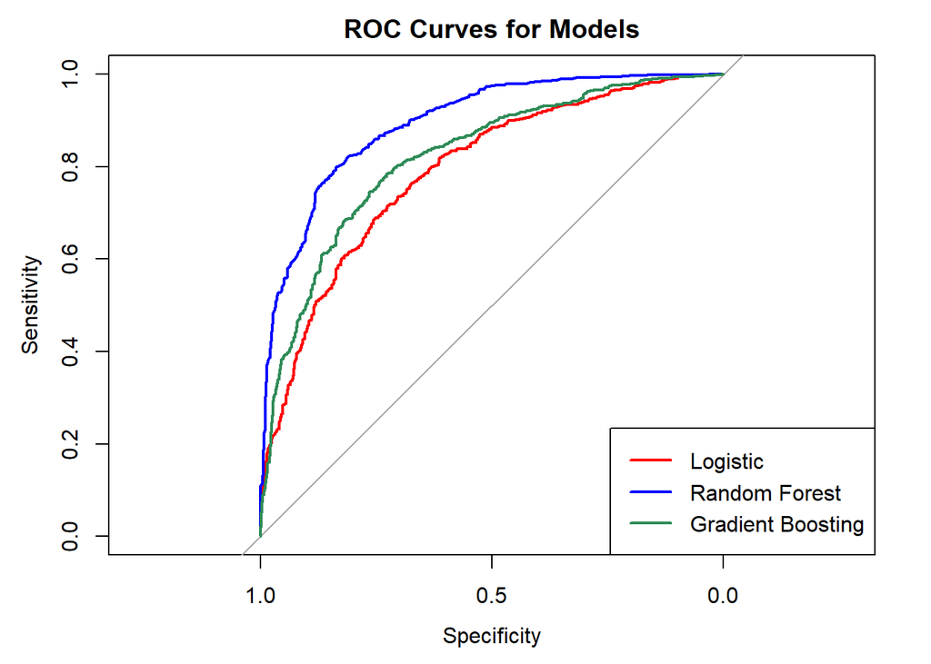

```r
plot(roc.log, col = "red", lwd = 2, main = "ROC Curves for Models")
plot(roc.rf, col = "blue", add = TRUE, lwd = 2)
plot(roc.gbm, col = "seagreen", add = TRUE, lwd = 2)
legend("bottomright", legend = c("Logistic", "Random Forest", "Gradient Boosting"),
       col = c("red", "blue", "seagreen"), lwd = 2)
```

The ROC curve shown in the overlay compares the performance of three models: Logistic Regression (red), Random Forest (blue), and Gradient Boosting (green). Here are the key inferences from the plot:

1. **Random Forest (blue)** performs the best, as its ROC curve is the furthest from the diagonal (representing random classification). This indicates that Random Forest has the highest true positive rate (sensitivity) and a low false positive rate (1-specificity), making it the most effective model at distinguishing between the two classes.
2. **Gradient Boosting (green)** is the second-best model, as its ROC curve is slightly above that of Logistic Regression. It shows a good balance of sensitivity and specificity, although not as optimal as Random Forest.
3. **Logistic Regression (red)** has the ROC curve closest to the diagonal, indicating its performance is closer to random guessing. This suggests that, compared to the other models, Logistic Regression struggles more in distinguishing between the classes.

Overall, **Random Forest** appears to be the most reliable model, followed by **Gradient Boosting**, with **Logistic Regression** being the least effective. The ROC curve confirms the AUC results, with Random Forest having the highest AUC and Logistic Regression having the lowest.